# Creating publication quality graphs in R

This tutorial was developped as part of a one-day workshop held within the Ecosystem Informatics PhD-programme at the Philipps University of Marburg. The contents of this tutorial are published under the creative commons license ['Attribution-ShareAlike CC BY-SA'](http://creativecommons.org/licenses/by-sa/3.0/).

Further information about this PhD programme can be found [here](http://ecosysteminformatics.org/phd-programm-ecosystem-informatics/)

To see what we are usually up to I refer the interested reader to our homepage at http://www.environmentalinformatics-marburg.de

Another resource for creating visualisations using R, more focussed on climatological/atmospheric applications can be found at http://metvurst.wordpress.com

I hope you find parts of this tutorial, if not all of it useful.

Comments, feedback, suggestions and bug reports should be directed to [tim.appelhans {at} staff.uni-marburg.de](http://umweltinformatik-marburg.de/mitarbeiterinnen-und-mitarbeiter/tim-appelhans/)

**In this workshop we will**

- learn a few things about handling and preparing our data for the creation of meaningful graphs
- quickly introduce the two main ways of plot creation in R - base graphics and grid graphics
- concentrate on plot production using grid graphics
- become familiar with the two main packages for highly flexible data visualisation in R - lattice & ggplot2 (biased towards lattice I have to admit)
- learn how to modify the default options of these packages in order to really get what we want
- learn even more flexibility using the grid package to create visualisations comprising multiple plots on one page and manipulate existing plots to suit our needs
- see how spatial data can be represented using the spatial packages available in R
- learn how to save our visualisations in different formats that comply with general publication standards of most academic journals

TIP: if you study the code provided in this tutorial closely, you will likely find some additional programming gems here and there which are not specifically introduced in this workshop… (such as the first two lines of code ;-))

**In this workshop it is assumed that you**

- already know how to get your data into R (`read.table()` etc)
- have a basic understanding how particular parts of your data can be assessed (`$`, `[` - in case you do not know what these special characters mean in an R sense, you might want to start at a more basic level, e.g. [here](http://tryr.codeschool.com/))
- are familiar the notion of object creation/assignment ( `<-` )

**Note, howerver, that this workshop is not about statistics (we will only be marginally exposed to very basic statistical principles)**

*Before we start, I would like to highlight a few useful web resources for finding help in case you get stuck with a particular task:*

- [google is your friend](http://www.google.com) - for R related questions just type something like this 'r lattice how to change plot background color' The crux here is that you provide both the programming language - R - and the name of the package your question is related to - lattice. This way you will very likely find useful answers (the web is full of knowledgeable geeks)
- for quick reference on the most useful basic functionality of R use http://www.statmethods.net
- using google in the way outlined above, you will most likely end up at [Stackoverflow](http://www.stackoverflow.com) at some stage. This is a very helpful platform for all sorts of programming issues with an ever increasing contribution of the R community. To search directly at Stackoverflow for R related stuff, type 'r' in front of you search.
- [Rseek](http://www.rseek.org) is a search site dedicated exclusively to R-related stuff.
- [R-Bloggers](http://www.r-bloggers.com) is a nice site that provides access to all sorts of blog sites dedicated to R from all around the world (in fact, a lot of the material of this workshop is derived from posts found there).
- last, but not least, I am hopeful that [this site](http://www.teachpress.environmentalinformatics-marburg.de) will continue to grow and hence provide more and more useful tutorials closely related to issued in environmental sciences. So keep checking this site…

## 1. Data handling

One thing that most people fail to acknowledge is that visualising data in R (or any other programming language for that matter) usually involves a little more effort than simply calling some plot function to create a meaningful graph. Data visualisation is in essence an abstract representation of raw data. Most plotting routines available in R, however, are not designed to provide any useful data abstraction. This means that it is up to us to prepare our data to a level of abstraction that is feasible for what we want to show with our visualisation.  
Therefore, before we start to produce plots, we will need to spend some time and effort get familiar with some tools to manipulate our raw data sets.

In particular, we will learn how to **subset**, **aggregate**, **sort** & **merge** our data sets.

**Right, enough of that introductory talk, let's start getting our hands dirty…**

### 1.1. sub-setting our data

**As a final introductory note I would like to draw your attention to the fact that for the sake of reproducibility, this workshop will make use of the diamonds data set (which comes with ggplot2) in all the provided examples**

First things first, as always in R, we load the necessary packages first (and this should always happen at the beginning of a script, not somewhere in the middle or towards the end!)

```r
### here's a rather handy way of loading all packages that you need
### for your code to work in one go
libs <- c('ggplot2', 'latticeExtra', 'gridExtra', 'MASS',
          'colorspace', 'plyr', 'Hmisc', 'scales')
lapply(libs, require, character.only = T)

### load the diamonds data set (comes with ggplot2)
data(diamonds)
```

The diamonds data set is structured as follows

```r
str(diamonds)
```

```
## 'data.frame':    53940 obs. of  10 variables:
##  $ carat  : num  0.23 0.21 0.23 0.29 0.31 0.24 0.24 0.26 0.22 0.23 ...
##  $ cut    : Ord.factor w/ 5 levels "Fair"<"Good"<..: 5 4 2 4 2 3 3 3 1 3 ...
##  $ color  : Ord.factor w/ 7 levels "D"<"E"<"F"<"G"<..: 2 2 2 6 7 7 6 5 2 5 ...
##  $ clarity: Ord.factor w/ 8 levels "I1"<"SI2"<"SI1"<..: 2 3 5 4 2 6 7 3 4 5 ...
##  $ depth  : num  61.5 59.8 56.9 62.4 63.3 62.8 62.3 61.9 65.1 59.4 ...
##  $ table  : num  55 61 65 58 58 57 57 55 61 61 ...
##  $ price  : int  326 326 327 334 335 336 336 337 337 338 ...
##  $ x      : num  3.95 3.89 4.05 4.2 4.34 3.94 3.95 4.07 3.87 4 ...
##  $ y      : num  3.98 3.84 4.07 4.23 4.35 3.96 3.98 4.11 3.78 4.05 ...
##  $ z      : num  2.43 2.31 2.31 2.63 2.75 2.48 2.47 2.53 2.49 2.39 ...
```

The `str()` command is probably the most useful command in all of R. It shows the complete structure of our data set and provides a 'road map' of how to access certain parts of the data.

For example

```
diamonds$carat
```

is a numerical vector of length 53940

and

```
diamonds$cut
```

is an ordered factor with the ordered levels Fair, Good, Very Good, Premium, Ideal

Suppose we're a stingy person and don't want to spend too much money on the wedding ring for our loved one, we could create a data set only including diamonds that cost less than 1000 US$ (though 1000 US$ does still seem very generous to me).

```r
diamonds.cheap <- subset(diamonds, price < 1000)
```

Then our new data set would look like this

```r
str(diamonds.cheap)
```

```
## 'data.frame':    14499 obs. of  10 variables:
##  $ carat  : num  0.23 0.21 0.23 0.29 0.31 0.24 0.24 0.26 0.22 0.23 ...
##  $ cut    : Ord.factor w/ 5 levels "Fair"<"Good"<..: 5 4 2 4 2 3 3 3 1 3 ...
##  $ color  : Ord.factor w/ 7 levels "D"<"E"<"F"<"G"<..: 2 2 2 6 7 7 6 5 2 5 ...
##  $ clarity: Ord.factor w/ 8 levels "I1"<"SI2"<"SI1"<..: 2 3 5 4 2 6 7 3 4 5 ...
##  $ depth  : num  61.5 59.8 56.9 62.4 63.3 62.8 62.3 61.9 65.1 59.4 ...
##  $ table  : num  55 61 65 58 58 57 57 55 61 61 ...
##  $ price  : int  326 326 327 334 335 336 336 337 337 338 ...
##  $ x      : num  3.95 3.89 4.05 4.2 4.34 3.94 3.95 4.07 3.87 4 ...
##  $ y      : num  3.98 3.84 4.07 4.23 4.35 3.96 3.98 4.11 3.78 4.05 ...
##  $ z      : num  2.43 2.31 2.31 2.63 2.75 2.48 2.47 2.53 2.49 2.39 ...
```

Now the new `diamonds.cheap` subset is a reduced data set of the original `diamonds` data set only having 14499 entries instead of the original 53940 entries.

In case we were interested in a subset only including all diamonds of quality (cut) 'Premium' the command would be

```r
diamonds.premium <- subset(diamonds, cut == "Premium")
str(diamonds.premium)
```

```
## 'data.frame':    13791 obs. of  10 variables:
##  $ carat  : num  0.21 0.29 0.22 0.2 0.32 0.24 0.29 0.22 0.22 0.3 ...
##  $ cut    : Ord.factor w/ 5 levels "Fair"<"Good"<..: 4 4 4 4 4 4 4 4 4 4 ...
##  $ color  : Ord.factor w/ 7 levels "D"<"E"<"F"<"G"<..: 2 6 3 2 2 6 3 2 1 7 ...
##  $ clarity: Ord.factor w/ 8 levels "I1"<"SI2"<"SI1"<..: 3 4 3 2 1 5 3 4 4 2 ...
##  $ depth  : num  59.8 62.4 60.4 60.2 60.9 62.5 62.4 61.6 59.3 59.3 ...
##  $ table  : num  61 58 61 62 58 57 58 58 62 61 ...
##  $ price  : int  326 334 342 345 345 355 403 404 404 405 ...
##  $ x      : num  3.89 4.2 3.88 3.79 4.38 3.97 4.24 3.93 3.91 4.43 ...
##  $ y      : num  3.84 4.23 3.84 3.75 4.42 3.94 4.26 3.89 3.88 4.38 ...
##  $ z      : num  2.31 2.63 2.33 2.27 2.68 2.47 2.65 2.41 2.31 2.61 ...
```

Note the **two** equal signs in order to specify our selection (this stems from an effort to be consistent with selection criteria such as *smaller than* `<=` or *not equal* `!=` and basically translates to *is equal*)!!

Any combinations of these subset commands are valid, e.g.

```r
diamonds.premium.and.cheap <- subset(diamonds, cut == "Premium" &
                                   price <= 1000)
```

produces a rather strict subset only allowing diamonds of premium quality that cost less than 1000 US$

In case we want **ANY** of these, meaning all diamonds of premium quality **OR** cheaper than 1000 US$, we would use the **|** operator to combine the two specifications

```r
diamonds.premium.or.cheap <- subset(diamonds, cut == "Premium" |
                                   price <= 1000)
```

The **OR** specification is much less rigid than the **AND** specification which will result in a larger data set:

- `diamonds.premium.and.cheap` has 3204 rows, while
- `diamonds.premium.or.cheap` has 25111 rows

```r
str(diamonds.premium.and.cheap)
```

```
## 'data.frame':    3204 obs. of  10 variables:
##  $ carat  : num  0.21 0.29 0.22 0.2 0.32 0.24 0.29 0.22 0.22 0.3 ...
##  $ cut    : Ord.factor w/ 5 levels "Fair"<"Good"<..: 4 4 4 4 4 4 4 4 4 4 ...
##  $ color  : Ord.factor w/ 7 levels "D"<"E"<"F"<"G"<..: 2 6 3 2 2 6 3 2 1 7 ...
##  $ clarity: Ord.factor w/ 8 levels "I1"<"SI2"<"SI1"<..: 3 4 3 2 1 5 3 4 4 2 ...
##  $ depth  : num  59.8 62.4 60.4 60.2 60.9 62.5 62.4 61.6 59.3 59.3 ...
##  $ table  : num  61 58 61 62 58 57 58 58 62 61 ...
##  $ price  : int  326 334 342 345 345 355 403 404 404 405 ...
##  $ x      : num  3.89 4.2 3.88 3.79 4.38 3.97 4.24 3.93 3.91 4.43 ...
##  $ y      : num  3.84 4.23 3.84 3.75 4.42 3.94 4.26 3.89 3.88 4.38 ...
##  $ z      : num  2.31 2.63 2.33 2.27 2.68 2.47 2.65 2.41 2.31 2.61 ...
```

```r
str(diamonds.premium.or.cheap)
```

```
## 'data.frame':    25111 obs. of  10 variables:
##  $ carat  : num  0.23 0.21 0.23 0.29 0.31 0.24 0.24 0.26 0.22 0.23 ...
##  $ cut    : Ord.factor w/ 5 levels "Fair"<"Good"<..: 5 4 2 4 2 3 3 3 1 3 ...
##  $ color  : Ord.factor w/ 7 levels "D"<"E"<"F"<"G"<..: 2 2 2 6 7 7 6 5 2 5 ...
##  $ clarity: Ord.factor w/ 8 levels "I1"<"SI2"<"SI1"<..: 2 3 5 4 2 6 7 3 4 5 ...
##  $ depth  : num  61.5 59.8 56.9 62.4 63.3 62.8 62.3 61.9 65.1 59.4 ...
##  $ table  : num  55 61 65 58 58 57 57 55 61 61 ...
##  $ price  : int  326 326 327 334 335 336 336 337 337 338 ...
##  $ x      : num  3.95 3.89 4.05 4.2 4.34 3.94 3.95 4.07 3.87 4 ...
##  $ y      : num  3.98 3.84 4.07 4.23 4.35 3.96 3.98 4.11 3.78 4.05 ...
##  $ z      : num  2.43 2.31 2.31 2.63 2.75 2.48 2.47 2.53 2.49 2.39 ...
```

There is, in principle, no limitation to the combination of these so-called Boolean operators (and, or, equal to, not equal to, greater than, less than). I guess you get the idea…

### ———————–~~ Exercise I ~~——————————

> create one subset of the diamonds dataframe which contains  
> only diamonds of quality 'Ideal' and a second subset that  
> contains the rest excluding all diamonds of color 'J'

### —————————-~~ ° ~~————————————–

### 1.2. aggregating our data

Suppose we wanted to calculate the average price of the diamonds for each level of `cut`, i.e. the average price for all diamonds of “Ideal” quality, for all diamonds of “Premium” quality and so on, this would be done like this

```r
ave.price.cut <- aggregate(diamonds$price, by = list(diamonds$cut),
                           FUN = mean)
### by = ... needs a list, even if there is only one entry
```

and will look like this

```r
ave.price.cut
```

```
##     Group.1    x
## 1      Fair 4359
## 2      Good 3929
## 3 Very Good 3982
## 4   Premium 4584
## 5     Ideal 3458
```

Note, that the original column names are not carried over to the newly created table of averaged values. Instead these get the generic names `Group.1` and `x`

The `Group.1` already indicates that we are not limited to aggregate just over one factorial variable, more are also possible. Furthermore, any function to compute the summary statistics which can be applied to all data subsets is allowed, e.g. to compute the number of items per category we could use `length`

```r
ave.n.cut.color <- aggregate(diamonds$price,
                             by = list(diamonds$cut,
                                       diamonds$color),
                             FUN = length)
ave.n.cut.color
```

```
##      Group.1 Group.2    x
## 1       Fair       D  163
## 2       Good       D  662
## 3  Very Good       D 1513
## 4    Premium       D 1603
## 5      Ideal       D 2834
## 6       Fair       E  224
## 7       Good       E  933
## 8  Very Good       E 2400
## 9    Premium       E 2337
## 10     Ideal       E 3903
## 11      Fair       F  312
## 12      Good       F  909
## 13 Very Good       F 2164
## 14   Premium       F 2331
```

[output cut: 21 more lines]

Given that as a result of aggregating this way we loose our variable names, it makes sense to set them afterwards, so that we can easily refer to them later

```r
names(ave.n.cut.color) <- c("cut", "color", "n")
str(ave.n.cut.color)
```

```
## 'data.frame':    35 obs. of  3 variables:
##  $ cut  : Ord.factor w/ 5 levels "Fair"<"Good"<..: 1 2 3 4 5 1 2 3 4 5 ...
##  $ color: Ord.factor w/ 7 levels "D"<"E"<"F"<"G"<..: 1 1 1 1 1 2 2 2 2 2 ...
##  $ n    : int  163 662 1513 1603 2834 224 933 2400 2337 3903 ...
```

So, I hope you see how useful `aggregate()` is for calculating summary statistics of your data.

### ———————–~~ Exercise II ~~—————————–

> aggregate the first dataframe from exercise I as mean carat  
> per clarity and the second one as median carat per clarity

### —————————–~~ ° ~~————————————

### 1.3. sorting our data

Sorting our data according to one (or more) of the variables in our data can also be very handy.  
Sorting of a vector can be achieved using `sort()`

```r
sort(ave.n.cut.color$n)
```

```
##  [1]  119  163  175  224  303  307  312  314  522  662  678  702  808  871
## [15]  896  909  933 1204 1428 1513 1603 1824 2093 2164 2299 2331 2337 2360
## [29] 2400 2834 2924 3115 3826 3903 4884
```

sorting of an entire dataframe is done using `order()` as follows

- for sorting according to one variable

```r
ave.n.cut.color <- ave.n.cut.color[order(ave.n.cut.color$cut), ]
ave.n.cut.color
```

```
##          cut color    n
## 1       Fair     D  163
## 6       Fair     E  224
## 11      Fair     F  312
## 16      Fair     G  314
## 21      Fair     H  303
## 26      Fair     I  175
## 31      Fair     J  119
## 2       Good     D  662
## 7       Good     E  933
## 12      Good     F  909
## 17      Good     G  871
## 22      Good     H  702
## 27      Good     I  522
## 32      Good     J  307
```

[output cut: 21 more lines]

- for sorting according to two variables

```r
ave.n.cut.color <- ave.n.cut.color[order(ave.n.cut.color$cut,
                                         ave.n.cut.color$n), ]
ave.n.cut.color
```

```
##          cut color    n
## 31      Fair     J  119
## 1       Fair     D  163
## 26      Fair     I  175
## 6       Fair     E  224
## 21      Fair     H  303
## 11      Fair     F  312
## 16      Fair     G  314
## 32      Good     J  307
## 27      Good     I  522
## 2       Good     D  662
## 22      Good     H  702
## 17      Good     G  871
## 12      Good     F  909
## 7       Good     E  933
```

[output cut: 21 more lines]

### ————————-~~ Exercise III ~~————————–

> sort the first data frame from exercise 2 according to carat

### ——————————-~~ ° ~~———————————–

### 1.4. merging our data

Often enough we end up with multiple data sets on our hard drive that contain useful data for the same analysis. In this case we might want to amalgamate our data sets so that we have all the data in one set.  
R provides a function called `merge()` that does just that

```r
ave.n.cut.color.price <- merge(ave.n.cut.color, ave.price.cut,
                               by.x = "cut", by.y = "Group.1")
ave.n.cut.color.price
```

```
##          cut color    n    x
## 1       Fair     J  119 4359
## 2       Fair     D  163 4359
## 3       Fair     I  175 4359
## 4       Fair     E  224 4359
## 5       Fair     H  303 4359
## 6       Fair     F  312 4359
## 7       Fair     G  314 4359
## 8       Good     J  307 3929
## 9       Good     I  522 3929
## 10      Good     D  662 3929
## 11      Good     H  702 3929
## 12      Good     G  871 3929
## 13      Good     F  909 3929
## 14      Good     E  933 3929
```

[output cut: 21 more lines]

As the variable names of our two data sets differ, we need to specifically provide the names for each by which the merging should be done (`by.x` & `by.y`). The default of `merge()` tries to find variable names which are identical.

Note, in order to merge more that two data frames at a time, we need to call a powerful higher order function called `Reduce()`. This is one mighty function for doing all sorts of things iteratively.

```r
names(ave.price.cut) <- c("cut", "price")

set.seed(12)

df3 <- data.frame(cut = ave.price.cut$cut,
                  var1 = rnorm(nrow(ave.price.cut), 10, 2),
                  var2 = rnorm(nrow(ave.price.cut), 100, 20))

ave.n.cut.color.price <- Reduce(function(...) merge(..., all=T),
                                list(ave.n.cut.color,
                                     ave.price.cut,
                                     df3))
ave.n.cut.color.price
```

```
##          cut color    n price   var1   var2
## 1       Fair     J  119  4359  7.039  94.55
## 2       Fair     D  163  4359  7.039  94.55
## 3       Fair     I  175  4359  7.039  94.55
## 4       Fair     E  224  4359  7.039  94.55
## 5       Fair     H  303  4359  7.039  94.55
## 6       Fair     F  312  4359  7.039  94.55
## 7       Fair     G  314  4359  7.039  94.55
## 8       Good     J  307  3929 13.154  93.69
## 9       Good     I  522  3929 13.154  93.69
## 10      Good     D  662  3929 13.154  93.69
## 11      Good     H  702  3929 13.154  93.69
## 12      Good     G  871  3929 13.154  93.69
## 13      Good     F  909  3929 13.154  93.69
## 14      Good     E  933  3929 13.154  93.69
```

[output cut: 21 more lines]

### ————————~~ Exercise IV ~~—————————-

> merge the two data frames from exercise II

### ——————————~~ ° ~~————————————

Ok, so now we have a few tools at hand to manipulate our data in a way that we should be able to produce some meaningful graphs which tell the story that we want to be heard, or better, seen…

So, let's start plotting stuff

## 2. Data visualisation

In the next few sections, we will produce several varieties of *scatter plots*, *box & whisker plots*, *plots with error bars*, *histograms* and *density plots*. All of these will first be produced using the `lattice` package and then an attempt is made to recreate these in (pretty much) the exact same way in `ggplot2`. First, the default versions are created and then we will see how they can be modified in order to produce plots that satisfy the requirements of most academic journals.

We will see that some things are easier to achieve using `lattice`, some other things are easier in `ggplot2`, so it is good to learn how to use both of them…

Ok, let's start with the classic statistical plot of variable x vs. variable y - the scatter plot…

### 2.1. Scatter plots

Even with all the enhancements & progress made in the field of computer based graphics in recent years/decades, the best (as most intuitive) way to show the relationship between two continuous variables remains the scatter plot. Just like for the smoothest ride, the best shape of the wheel is still round.

If, from our original diamonds data set we wanted to see the relation between price and carat of the diamonds (or more precisely how price is influenced by carat), we would use a scatter plot.

#### 2.1.1. The *lattice* way

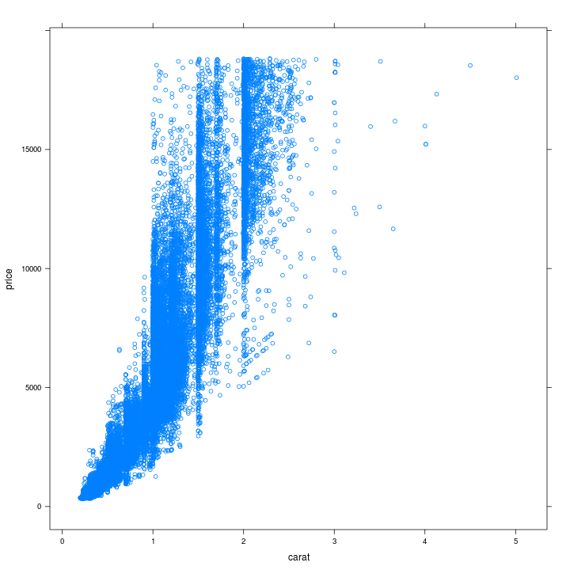

Figure 1: a basic scatter plot produced with lattice

```r
scatter.lattice <- xyplot(price ~ carat, data = diamonds)

scatter.lattice
```

What we see is that generally lower carat values tend to be cheaper.

However, there is, especially at the high price end, a lot of scatter, i.e. there are diamonds of 1 carat that cost just as much as diamonds of 4 or more carat. Maybe this is a function of the cut? Let's see…

Lattice is a very powerful package that provides a lot of flexibility and power to create all sorts of taylor-made statistical plots. In particular, it is designed to provide an easy to use framework for the representation of some variable(s) conditioned on some other variable(s). This means, that we can easily show the same relationship from figure 1, but this time for each of the different quality levels (the variable `cut` in the diamonds data set) into which diamonds can be classified. These conditional subsets are called panels in lattice.

This is done using the `|` character just after the formula expression. So the complete formula would read:

```
y ~ x | g
```

y is a function of x conditional to the values of g (where g is usually a factorial variable)

The code below shows how all of this is achieved.

- plot `price ~ carat` conditional to `cut`
- draw the regression line for each panel
- also provide the *R<sup>2</sup>* value for each panel

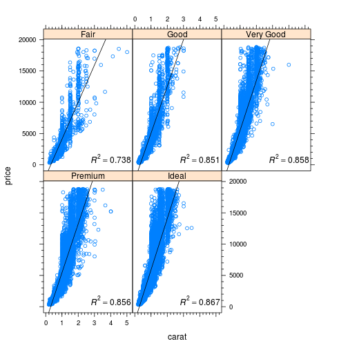

Figure 2: a panel plot showing regression lines for each panel produced with lattice

```r
scatter.lattice <- xyplot(price ~ carat | cut,
                          data = diamonds,
                          panel = function(x, y, ...) {
                            panel.xyplot(x, y, ...)
                            lm1 <- lm(y ~ x)
                            lm1sum <- summary(lm1)
                            r2 <- lm1sum$adj.r.squared
                            panel.abline(a = lm1$coefficients[1],
                                         b = lm1$coefficients[2])
                            panel.text(labels =
                                         bquote(italic(R)^2 ==
                                                  .(format(r2,
                                                           digits = 3))),
                                       x = 4, y = 1000)
                            },
                          xscale.components = xscale.components.subticks,
                          yscale.components = yscale.components.subticks,
                          as.table = TRUE)

scatter.lattice
```

This is where `lattice` becomes a bit more challenging, yet how do they say: with great power comes great complexity… (maybe I didn't get this quote completely correct, but it certainly reflects the nature of `lattice's` flexibility. A lot of things are possible, but they need a bit more effort than accepting the default settings.

Basically, what we have done here is to provide a so-called panel function (actually, we have provided 3 of them).

But let's look at this step-by-step…

As `lattice` is geared towards providing plots in small multiples (as E. Tufte calls them) or panels it provides a `panel =` argument to which we can assign certain functions that will be evaluated separately for each of the panels. There's a variety of pre-defined panel functions (such as the ones we used here - panel.xyplot, panel.abline, panel.text & many more) but we can also define out own panel functions. This is why `lattice` is so versatile and powerful. Basically, writing panel functions is just like writing any other function in R (though some limitations do exist).

The important thing to note here is that `x` and `y` in the context of panel functions refer to the `x` and `y` variables we define in the plot definition, i.e. `x = carat` and `y = price`. So, for the panel functions we can use these shorthands, like as we are doing in defining our linear model `lm1 <- lm(y ~ x)`. This linear model will be calculated separately for each of the panels, which are basically nothing else than subsets of our data corresponding to the different levels of cut. Maybe it helps to think of this as a certain type of for loop:

```
for (level in levels(cut)) lm1 <- lm(price ~ carat)
```

This then enables us to access the outcome of this linear model separately for each panel and we can use `panel.abline` to draw a line in each panel corresponding to the calculated model coefficients `a = Intercept` and `b = slope`. Hence, we are drawing the regression line which represents the line of least squares for each panel separately.

The same holds true for the calculation and plotting of the adjusted *R<sup>2</sup>* value for each linear model per panel. In this case we use the `panel.text` function to 'write' the corresponding value into each of the panel boxes. The location of the text is determined by the `x =` and `y =` arguments. This is where some car needs to be taken, as in the `panel.text` call `x` and `y` don't refer to the `x` and `y` variables of the global plot function (`xyplot`) anymore, but rather represent the locations of where to position the text within each of the panel boxes in the units used for each of the axes (in our case `x = 4` and `y = 1000`).

There's two more things to note with regard to panel functions

1. In order to draw what we originally intended to draw, i.e. the scatterplot, we need to provide a panel function that represents our initial intention. In our case this is the rather blank call `panel.xyplot(x, y, ...)`. Without this, the points of our plot will not be drawn and we will get a plot that only shows the regression line and the text (feel free to try it!). This seems like a good place to introduce one of the most awkward (from a programming point of view) but at the same time most awesome (from a users point of view) things in the R language. The `...` are a shorthand for 'everything else that is possible in a certain function'. This is both a very lazy and at the same time a very convenient way of passing arguments to a function. Basically, this enables us to provide any additional argument that the function might be able to understand. Any argument that `xyplot` is able to evaluate (understand) can be passed in addition to `x` and `y`. Try it yourself by, for example specifying `col = "red"`. If we had not included `, ...` in the `panel = function(x, y, ...)` argument, the `col =` definition would not be possible. Anyway, this is only a side note that is not really related to the topic at hand, so let's move on….
2. the order in which panel functions are supplied does matter. This means that the first panel function will be evaluated (and drawn) first, then the second, then the third and so on. Hence, if we were to plot the points of our plot on top of everything else, we would need to provide the `panel.xyplot` function as the last of the panel functions.

Right, so now we have seen how to use panel functions to calculate and draw things specific to each panel. One thing I really dislike about `lattice` is the default graphical parameter settings (such as colours etc). However, changing these is rather straight forward. We can easily create our own themes by replacing the default values for each of the graphical parameters individually and saving these as our own themes. The function that let's us access the default (or already modified) graphical parameter settings is called `trellis.par.get()`. Assigning this to a new object, we can modify every entry of the default settings to our liking (remember `str()` provides a 'road map' for accessing individual bits of an object).

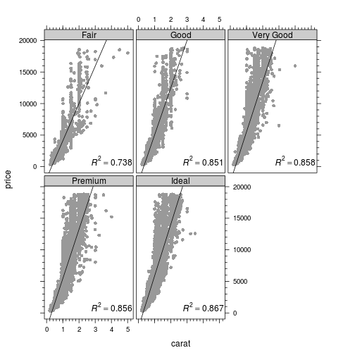

Figure 3: a panel plot with modified settings of the lattice layout

```r
my.theme <- trellis.par.get()
my.theme$strip.background$col <- "grey80"
my.theme$plot.symbol$pch <- 16
my.theme$plot.symbol$col <- "grey60"
my.theme$plot.polygon$col <- "grey90"

l.sc <- update(scatter.lattice, par.settings = my.theme,
               layout = c(3, 2),
               between = list(x = 0.3, y = 0.3))

print(l.sc)
```

Apart from showing us how to change the graphical parameter settings, the above code chunk also highlights one of the very handy properties of `lattice` (which is also true for `ggplot2`). We are able to store any plot we create in an object and can refer to this object later. This enables us to simply `update` the object rather than having to define it over (and over) again.

Like many other packages, `lattice` has a companion called `latticeExtra`. This package provides several additions/extensions to the core functionality of `lattice`. One of the very handy additions is a panel function called `panel.smoother` which enables us to evaluate several linear and non-linear models for each panel individually. This means that we actually don't need to calculate these models 'by hand' for each panel, but can use this pre-defined function to evaluate them. This is demonstrated in the next code chunk.

Note that we are still calculating the linear model in order to be able to provide the *R<sup>2</sup>* value for each panel. We don't need the `panel.abline` anymore to draw the regression line anymore. Actually, this is done using `panel.smoother` which also provides us with an estimation of the standard error related to the mean estimation of `y` for each `x`. This may be hard to see, but there is a confidence band of the standard error plotted around the regression line in each panel. Note, unfortunately, the the confidence intervals are very narrow so that they are hard to see in the plot below.

For an overview of possible models to be specified using `panel.smoother` see `?panel.smoother` (in library `latticeExtra`)

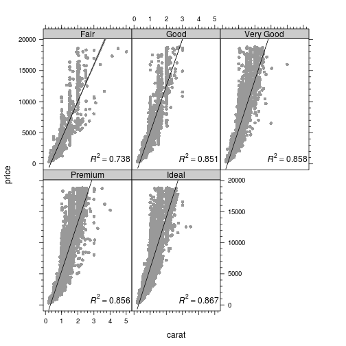

Figure 4: a panel plot showing regression lines and confidence intervals for each panel produced with lattice

```r
scatter.lattice <- xyplot(price ~ carat | cut,
                          data = diamonds,
                          panel = function(x, y, ...) {
                            panel.xyplot(x, y, ...)
                            lm1 <- lm(y ~ x)
                            lm1sum <- summary(lm1)
                            r2 <- lm1sum$adj.r.squared
                            panel.text(labels =
                                         bquote(italic(R)^2 ==
                                                  .(format(r2,
                                                           digits = 3))),
                                       x = 4, y = 1000)
                            panel.smoother(x, y, method = "lm",
                                           col = "black",
                                           col.se = "black",
                                           alpha.se = 0.3)
                            },
                          xscale.components = xscale.components.subticks,
                          yscale.components = yscale.components.subticks,
                          as.table = TRUE)

l.sc <- update(scatter.lattice, par.settings = my.theme)

print(l.sc)
```

Having a look at the scatter plots we have produced so far, there is an obvious problem. There are so many points that it is impossible to determine their actual distribution. One way to address this problem could be to plot each point in a semi-transparent manner. I have tried this potential solution and found that it does not help a great deal (but please feel free, and I highly encourage, to try it yourself).

Hence, we need another way to address the over-plotting of points.

This colour space is readily available in R through the package `colorspace` and the function of interest is called `hcl()`.

In the code chunk that follows we will create a colour palette that varies in both colour (hue) and also luminance (brightness) so that this can be distinguished even in grey-scale (printed) versions of the plot. As a reference colour palette we will use the 'Spectral' palette from clorobrewer.org which is also a multi-hue palette but represents a diverging colour palette. Hence, each end of the palette will look rather similar when converted to grey-scale.

```r
clrs.spec <- colorRampPalette(rev(brewer.pal(11, "Spectral")))
clrs.hcl <- function(n) {
  hcl(h = seq(230, 0, length.out = n),
      c = 60, l = seq(10, 90, length.out = n),
      fixup = TRUE)
  }

### function to plot a colour palette
pal <- function(col, border = "transparent", ...)
{
 n <- length(col)
 plot(0, 0, type="n", xlim = c(0, 1), ylim = c(0, 1),
      axes = FALSE, xlab = "", ylab = "", ...)
 rect(0:(n-1)/n, 0, 1:n/n, 1, col = col, border = border)
}
```

So here's the Spectral palette from colorbrewer.org interpolated over 100 colours

```r
pal(clrs.spec(100))
```

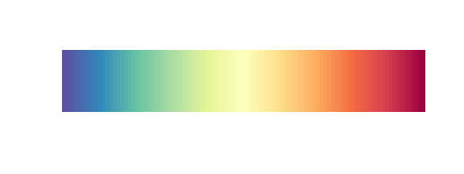

Figure 5: a diverging rainbow colour palette from colorbrewer

And this is what it looks like in grey-scale

```r
pal(desaturate(clrs.spec(100)))
```

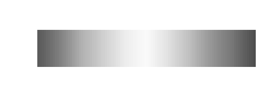

Figure 6: same palette as above in grey-scale

We see that this palette varies in lightness from a very bright centre to darker ends on each side. Note, that the red end is slightly darker than the blue end

This is quite ok in case we want to show some diverging data (deviations from a zero point - e.g. the mean). If we, however, are dealing with a sequential measure, such as temperature, or in our case the density of points plotted per some grid cell, we really need to use a sequential colour palette. There are two common problems with sequential palettes:

1. we need to create a palette that maps the data accurately. This means that the perceived distances between the different hues utilised needs to reflect the distances between our data points. AND this distance needs to be constant, no matter between which two point of the palette we want to estimate their distance. Let me give you an example. Consider the classic 'rainbow' palette (Matlab refers to this as 'jet colors')

```r
pal(rainbow(100))
```

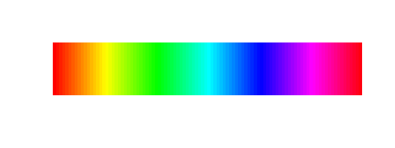

Figure 7: the classic rainbow colour palette

It becomes obvious that there are several thin bands in this colour palette (yellow, aquamarine, purple) which do not map the distances between variable values accurately. That is, the distance between two values located in/around the yellow region of the palette will seem to change faster than, for example somewhere in the green region (and red and blue).

When converted to grey-scale this palette produces a hell of a mess…

```r
pal(desaturate(rainbow(100)))
```

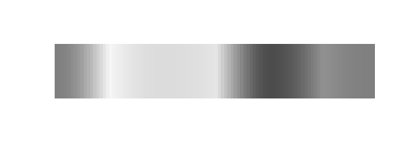

Figure 8: same palette as above in grey-scale

Note, that this palette is maybe the most widely used colour coding palette for mapping a sequential continuous variable to colour. We will see further examples later on…

I hope you get the idea that this is not a good way of mapping a sequential variable to colour!

`hcl()` produces so-called perceptually uniform colour palettes and is therefore much better suited to represent sequential data.

```r
pal(clrs.hcl(100))
```

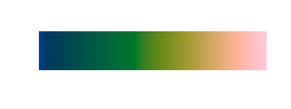

Figure 9: an hcl based multi-hue colour palette with increasing luminence towards the red end

We see that the different hues are spread constantly over the palette and therefore it is easy to estimate distances between data values from the changes in colour.  
The fact that we also vary luminance here means that we get a very light colour at one end (here the red end - which is a more of a pink tone than red). This might, at first sight, not seem very aesthetically pleasing, yet it enables us to encode our data even in grey-scale…

```r
pal(desaturate(clrs.hcl(100)))
```

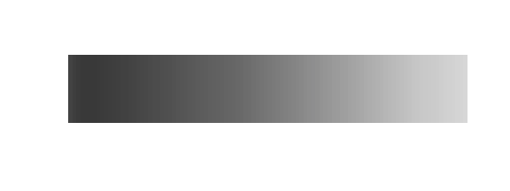

Figure 10: same palette as above in grey-scale

As a general suggestion I encourage you to make use of the hcl colour space whenever you can. But most importantly, it is essential to do some thinking before mapping data to colour. The most basic question you always need to ask yourself is **what is the nature of the data that I want to show? - sequential, diverging or qualitative?** Once you know this, it is easy to choose the appropriate colour palette for the mapping. A good place to start for choosing perceptually well thought through palettes is [the colorbrewer website](http://www.colorbrewer2.org).

Right, so now that we have established some principles about colour representation, we can go ahead and use this to show the density of the points in our scatter plot.

To do this we need a so-called '2 dimensional kernel density estimator'. I won't go into much detail about the density estimation here. What is important for our purpose is that we actually need to estimate this twice. Once globally, meaning for the whole data set, in order to find the absolute extremes (minimum and maximum) of our data distribution. This is important for the colour mapping, because the values of each panel need to be mapped to a common scale in order to interpret them. In other words, this way we are making sure that the similar values of our data are represented by similar shades of, let's say red.

However, in order to be able to estimate the density for each of our panels we also need to do the same calculation in our panel function.

Essentially what we are creating is a gridded data set (like a photo) of the density of points within each of the defined pixels. The `lattice` function for plotting gridded data is called `levelplot()`.

Here's the code

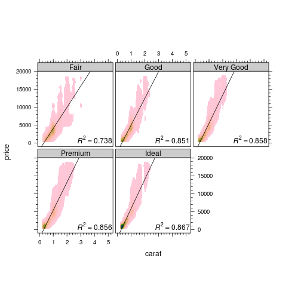

Figure 11: a lattice panel plot showing the point density within each panel

```r
xy <- kde2d(x = diamonds$carat, y = diamonds$price, n = 100)
xy.tr <- con2tr(xy)
offset <- max(xy.tr$z) * 0.2
z.range <- seq(min(xy.tr$z), max(xy.tr$z) + offset, offset * 0.01)

l.sc <- update(scatter.lattice, aspect = 1, par.settings = my.theme,
               between = list(x = 0.3, y = 0.3),
               panel=function(x,y) {
                 xy <- kde2d(x,y, n = 100)
                 xy.tr <- con2tr(xy)
                 panel.levelplot(xy.tr$x, xy.tr$y, xy.tr$z, asp = 1,
                                 subscripts = seq(nrow(xy.tr)),
                                 contour = FALSE, region = TRUE,
                                 col.regions = c("white",
                                                 rev(clrs.hcl(10000))),
                                 at = z.range)
                 lm1 <- lm(y ~ x)
                 lm1sum <- summary(lm1)
                 r2 <- lm1sum$adj.r.squared
                 panel.abline(a = lm1$coefficients[1],
                              b = lm1$coefficients[2])
                 panel.text(labels =
                              bquote(italic(R)^2 ==
                                       .(format(r2, digits = 3))),
                            x = 4, y = 1000)
                 #panel.xyplot(x,y)
                 }
               )

print(l.sc)
```

It should not go unnoticed that there is a panel function in `lattice` that does this for you. The function is called `panel.smoothScatter()` and unless we need to specify a custom colour palette, this is more than sufficient.

As a hint, if you want to use this panel function with your own colour palette you need to make sure that your palette starts with white as otherwise things will look really weird…

```r
l.sc.smooth <- update(scatter.lattice, aspect = 1,
                      par.settings = my.theme,
                      between = list(x = 0.3, y = 0.3),
                      panel = panel.smoothScatter)

print(l.sc.smooth)
```

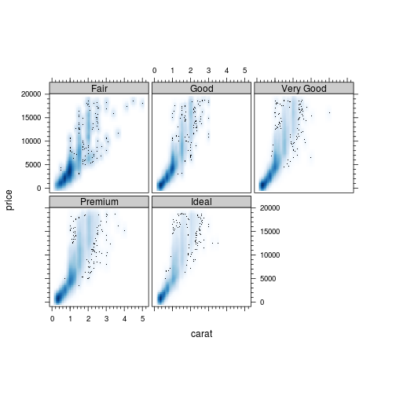

Figure 12: a lattice panel plot showing the point density within each panel using the panel function smoothScatter()

This representation of our data basically adds another dimension to our plot which enables us to see that no matter what the quality of the diamond, most of the diamonds are actually of low carat and low price. Whether this is good or bad news, depends on your interpretation (and the size of your wallet, of course).

#### 2.1.2. The *ggplot2* way

Now let's try to recreate what we have achieved with `lattice` using `ggplot2`.

`ggplot2` is radically different from the way that `lattice` works. `lattice` is much closer to the traditional way of plotting in R. There are different functions for different types of plots. In `ggplot2` this is different. Every plot we want to draw, is, at a fundamental level, created in exactly the same way. What differs are the subsequent calls on how to represent the individual plot components (basically `x` and `y`). This means a much more consistent way of *building* visualisations, but it also means that things are rather different from what you might have learned about syntax and structure of (plotting) objects in R. But not to worry, even I managed to understand how thing are done in `ggplot2` (and prior to writing this I had almost never used it before).

Before I get carried away too much let's jump right into our first plot using `ggplot2`

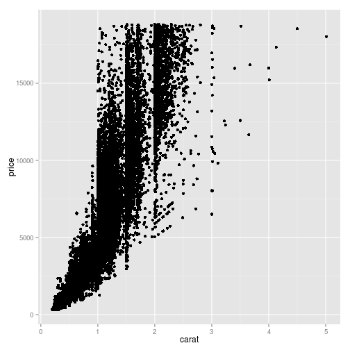

Figure 13: a basic scatter plot created with ggplot2

```r
scatter.ggplot <- ggplot(aes(x = carat, y = price), data = diamonds)

g.sc <- scatter.ggplot + geom_point()

print(g.sc)
```

Similar to `lattice`, plots are (usually) stored in objects. But that is about all the similarity there is.

Let's look at the above code in a little more detail. The first line is the fundamental definition of **what** we want to plot. We provide the 'aesthetics' for the plot (`aes()`) We state that we want the values on the x-axis to represent carat and the y-values are price. The data set to take these variables from is the diamonds data set. That's basically it, and this will not change a hell of a lot in the subsequent plotting routines.

What will change in the plotting code chunks that follow is **how** we want the relationship between these variables to be represented in our plot. This is done by defining so-called geometries (`geom_...()`). In this first case we stated that we want the relationship between `x` and `y` to be represented as points, hence we used `geom_point()`.

If we wanted to provide a plot showing the relationship between price and carat in panels representing the quality of the diamonds, we need what in `gglot2` is called facetting (panels in `lattice`). To achieve this, we simply repeat our plotting call from earlier and add another layer to the call which does the facetting.

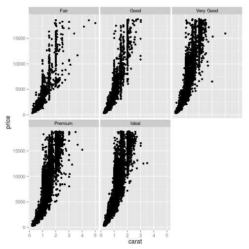

Figure 14: ggplot2 version of a facetted plot

```r
g.sc <- scatter.ggplot +
  geom_point() +
  facet_wrap(~ cut)

print(g.sc)
```

One thing that some people dislike about the default settings in `ggplot2` is the grey background of the plots. This grey background is, in my opinion, a good idea when colors are involved as it tends to increase the contrast of the colours. If, however, the plot is a simple black-and-white scatter plot as in our case here, a white panel, or better facet background seems more reasonable. We can easily change this using a pre-defined theme called `theme_bw()`.

In order to provide the regression line for each panel like we did in `lattice`, we need a function called `stat_smooth()`. This is fundamentally the same function that we used earlier, as the `panel.smoother()` in `lattice` is based on `stat_smooth()`.

Putting this together we could do something like this (note that we also change the number of rows and columns into which the facets should be arranged):

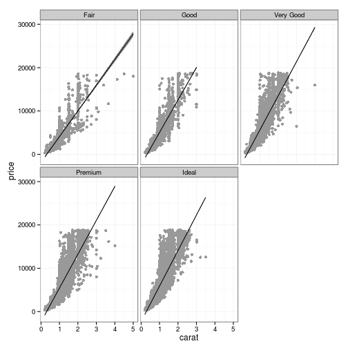

Figure 15: a ggplot2 panel plot with modified theme and added regression lines and confidence bands for each panel

```r
g.sc <- scatter.ggplot +
  #geom_tile() +
  geom_point(colour = "grey60") +
  facet_wrap(~ cut, nrow = 2, ncol = 3) +
  theme_bw() +
  stat_smooth(method = "lm", se = TRUE,
              fill = "black", colour = "black")

print(g.sc)
```

Simple and straight forward, and the result looks rather similar to the `lattice` version we created earlier.

Creating a point density scatter plot in `ggplot2` is actually a fair bit easier than in `lattice`, as `gglot2` provides several predefined `stat_...()` function calls. One of these is designed to create 2 dimensional kernel density estimations, just what we want. However, this is where the syntax of `ggplot2` really becomes a bit abstract. he definition of the fill argument of this call is `..density..`, which, at least to me, does not seem very intuitive.

Furthermore, it is not quite sufficient to supply the stat function, we also need to state how to map the colours to that stat definition. Therefore, we need yet another layer which defines what colour palette to use. As we want a continuous variable (density) to be filled with a gradient of n colours, we need to use `scale_fill_gradientn()` in which we can define the colours we want to be used.

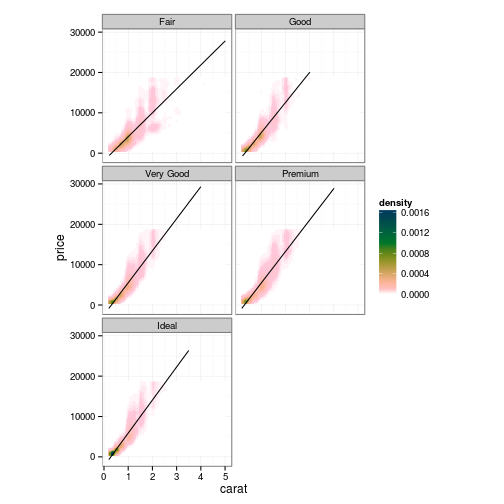

Figure 16: ggplot2 version of a panel plot showing point densities in each panel

```r
g.sc <- scatter.ggplot +
  geom_tile() +
  #geom_point(colour = "grey60") +
  facet_wrap(~ cut, nrow = 3, ncol = 2) +
  theme_bw() +
  stat_density2d(aes(fill = ..density..), n = 100,
                 geom = "tile", contour = FALSE) +
  scale_fill_gradientn(colours = c("white",
                                   rev(clrs.hcl(100)))) +
  stat_smooth(method = "lm", se = FALSE, colour = "black") +
  coord_fixed(ratio = 5/30000)

print(g.sc)
```

### ————————~~ Exercise V ~~—————————–

> create a lattice & a ggplot2 scatterplot of mean (y) vs. median (x)  
> carat using the merged data set from exercise IV both with  
> standard confidence intervals

### ——————————~~ ° ~~————————————

### 2.2. Box an whisker plots

I honestly don't have a lot to say about box and whisker plots. They are probably the most useful plots for showing the nature/distribution of your data and allow for some easy comparisons between different levels of a factor for example.

see http://upload.wikimedia.org/wikipedia/commons/1/1a/Boxplot_vs_PDF.svg for a visual representation of the standard R settings of BW plots in relation to mean and standard deviation of a normal distribution.

So without further ado, here's a basic lattice box and whisker plot.

#### 2.2.1. The *lattice* way

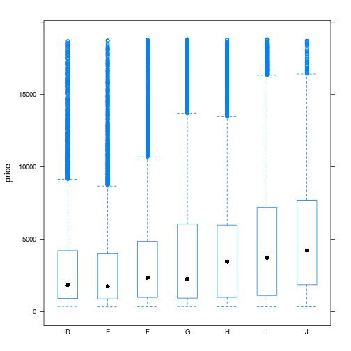

Figure 17: a basic box-whisker-plot produced with lattice

```r
bw.lattice <- bwplot(price ~ color, data = diamonds)

bw.lattice
```

Not so very beautiful… So, let's again modify the standard `par.settings` so that we get an acceptable box and whisker plot.

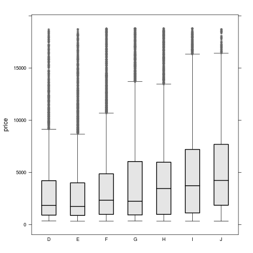

Figure 18: lattice bw-plot with modified graphical parameter settings

```r
bw.theme <- trellis.par.get()
bw.theme$box.dot$pch <- "|"
bw.theme$box.rectangle$col <- "black"
bw.theme$box.rectangle$lwd <- 2
bw.theme$box.rectangle$fill <- "grey90"
bw.theme$box.umbrella$lty <- 1
bw.theme$box.umbrella$col <- "black"
bw.theme$plot.symbol$col <- "grey40"
bw.theme$plot.symbol$pch <- "*"
bw.theme$plot.symbol$cex <- 2
bw.theme$strip.background$col <- "grey80"

l.bw <- update(bw.lattice, par.settings = bw.theme)

print(l.bw)
```

Much better, isn't it?

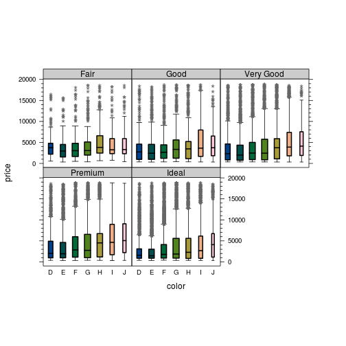

Figure 19: a lattice panel bw-plot with box widths relative to number of observations and coloured boxes

```r
bw.lattice <- bwplot(price ~ color | cut, data = diamonds,
                     asp = 1, as.table = TRUE, varwidth = TRUE)
l.bw <- update(bw.lattice, par.settings = bw.theme, xlab = "color",
               fill = clrs.hcl(7),
               xscale.components = xscale.components.subticks,
               yscale.components = yscale.components.subticks)

print(l.bw)
```

In addition to the rather obvious provision of a color palette to to fill the boxes, in this final box & whisker plot we have also told `lattice` to adjust the widths of the boxes so that they reflect the relative sizes of the data samples for each of the factors (colours). This is a rather handy way of providing insight into the data distribution along the factor of the x-axis. We can show this without having to provide any additional plot to highlight that some of the factor levels (i.e. colours) are much less represented than others ('J' compared to 'G', for example, especially for the 'Ideal' quality class).

#### 2.2.2. The *ggplot2* way

As much as I love `lattice`, I always end up drawing box and whisker plots with `ggplot2` because they look so much nicer and there's no need to modify so many graphical parameter settings in order to get an acceptable result.

You will see what I mean when we plot a `ggplot2` version using the default settings.

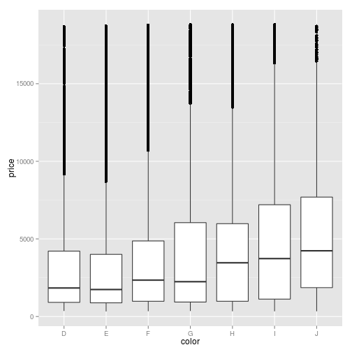

Figure 20: a basic ggplot2 bw-plot

```r
bw.ggplot <- ggplot(diamonds, aes(x = color, y = price))

g.bw <- bw.ggplot + geom_boxplot()

print(g.bw)
```

This is much much better straight away!!

And, as we've already seen, the facetting is also just one more line…

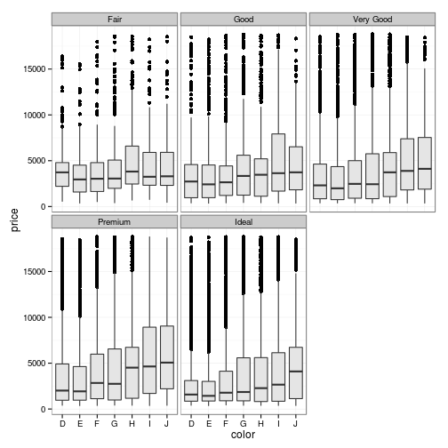

Figure 21: ggplot2 panel bw-plot

```r
bw.ggplot <- ggplot(diamonds, aes(x = color, y = price))

g.bw <- bw.ggplot +
  geom_boxplot(fill = "grey90") +
  theme_bw() +
  facet_wrap(~ cut)

print(g.bw)
```

So far, you may have gotten the impression that pretty much everything is a little bit easier the `ggplot2` way. Well, a lot of things are, but some are not. If we wanted to highlight the relative sample sizes of the different colour levels like we did earlier in `lattice` (using `varwidth = TRUE`) we have to put a little more effort into `ggplot2`. Meaning, we have to calculate this ourselves. There is no built in functionality for this feature (yet), at least none that I am aware of.

But, it is not too complicated. The equation for this adjustment is rather straight forward, we simply take the square root of the counts for each colour and divide it by the overall number of observations. Then we standardise this relative to the maximum of this calculation. As a final step, we need to break this down to each of the panels of the plot. This is the toughest part of it. I won't go into any detail here, but the `llply` pat of the following code chunk is basically the equivalent of what is going on behind the scenes of `lattice` (though `lattice` most likely does not use `llply`).

Anyway, it does not require too many lines of code to achieve the box width adjustment in `ggplot2`.

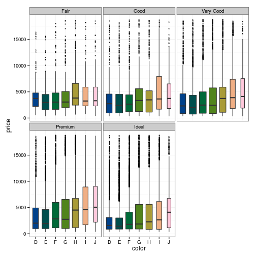

Figure 22: a ggplot2 panel bw-plot with box widths relative to number of observations and coloured boxes

```r
w <- sqrt(table(diamonds$color)/nrow(diamonds))
### standardise w to maximum value
w <- w / max(w)

g.bw <- bw.ggplot +
  facet_wrap(~ cut) +
  llply(unique(diamonds$color),
        function(i) geom_boxplot(fill = clrs.hcl(7)[i],
                                 width = w[i], outlier.shape = "*",
                                 outlier.size = 3,
                                 data = subset(diamonds, color == i))) +
  theme_bw()

print(g.bw)
```

The result is very very similar to what we have achieved earlier with `lattice`. In summary, lattice needs a little more care to adjust the standard graphical parameters, whereas `ggplot2` requires us to manually calculate the width of the boxes. I leave it up to you, which way suits you better… I have already made my choice a few years ago ;-)

Boxplots are, as mentioned above, a brilliant way to visualise data distribution(s). Their strength lies in the comparability of different classes as they are plotted next to each other using a common scale. Another, more classical - as parametric - way are histograms (and densityplots).

### 2.2. Histograms & densityplots

The classic way to visualise the distribution any data are histograms. They are closely related to density plots, where the individual data points are not binned into certain classes but a continuous density function is calculated to show the distribution. Both approaches reflect a certain level of abstraction (binning vs. functional representation), therefore a general formulation of which of them is more accepted is hard. In any case, the both achieve exactly the same result, they will show us the distribution of our data.

#### 2.2.1. The *lattice* way

As is to be expected with `lattice`, the default plotting routine does not really satisfy the (or maybe better my) aesthetic expectations.

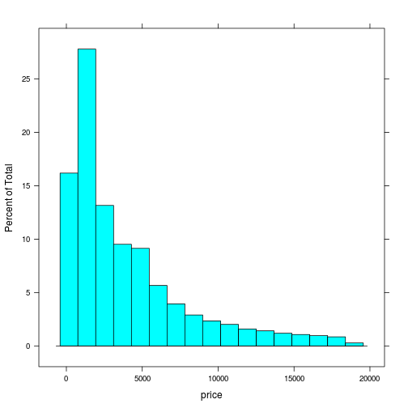

Figure 23: a basic histogram produced with lattice

```r
hist.lattice <- histogram(~ price, data = diamonds)
hist.lattice
```

This is even worse for the default density plot…

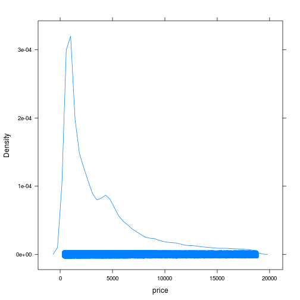

Figure 24: a basic density plot produced with lattice

```r
dens.lattice <- densityplot(~ price, data = diamonds)
dens.lattice
```

Yet, as we've already adjusted our global graphical parameter settings, we can now easily modify this.

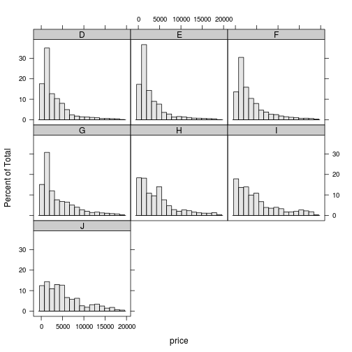

Figure 25: a panel histogram with modofied graphical parameter settings

```r
hist.lattice <- histogram(~ price | color,
                          data = diamonds,
                          as.table = TRUE,
                          par.settings = my.theme)

l.his <- hist.lattice

print(l.his)
```

Now, this is a plot that every journal editor will very likely accept.

Until now, we have seen how to condition our plots according to one factorial variable (`diamonds$cut`). It is, in theory, possible to condition plots on any number of factorial variable, though more than two is seldom advisable. Two, however, is definitely acceptable and still easy enough to perceive and interpret. In `lattice` this is generally done as follows.

```
y ~ x | g + f
```

where `g` and `f` are the factorial variables used for the conditioning.

In the below code chunk we are first creating out plot object and the we are using a function called `useOuterStrips()` which makes sure that the strips that correspond to the conditioning variables are plotted on both the top and the left side of our plot. The default `lattice` setting is to plot both at the top, which makes the navigation through the plot by the viewer a little more difficult.

Another default setting for densityplots in `lattice` is to plot a point (circle) for each observation of our variable (price) at the bottom of the plot along the x–axis. In our case, as we have a lot of data points, this is not desirable, so we set the argument `plot.points` to `FALSE`.

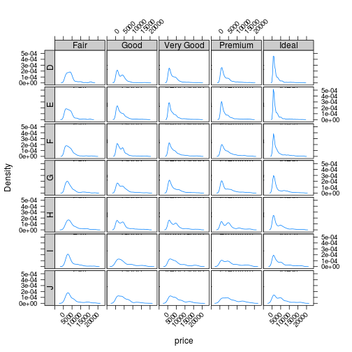

Figure 26: a panel density plot conditioned according to 2 variables using lattice

```r
dens.lattice <- densityplot(~ price | cut + color,
                            data = diamonds,
                            as.table = TRUE,
                            par.settings = my.theme,
                            plot.points = FALSE,
                            between = list(x = 0.2, y = 0.2),
                            scales = list(x = list(rot = 45)))

l.den <- useOuterStrips(dens.lattice)

print(l.den)
```

You may have noticed that the lines of the densityplot are plotted in a light shade of blue (cornflowerblue to be precise). I it up to you to change this yourself…

Another thing you may notice when looking at the above plot is that the x-axis labels are rotated by 45 degrees. This one I also leave up to you to figure out… ;-)

#### 2.2.2. The *ggplot2* way

Much like with the box and whisker plot, the default settings of `ggplot2` are quite a bit nicer for both histogram and densityplot.

```
## stat_bin: binwidth defaulted to range/30. Use 'binwidth = x' to adjust
## this.
```

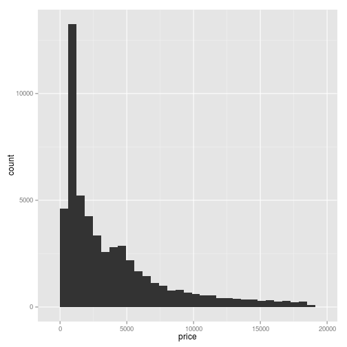

Figure 27: a basic histogram produced with ggplot2

```r
hist.ggplot <- ggplot(diamonds, aes(x = price))

g.his <- hist.ggplot +
  geom_histogram()

print(g.his)
```

One thing that is really nice about the `ggplot2` densityplots that it is so easy to fill the area under the curve which really helps the visual representation of the data.

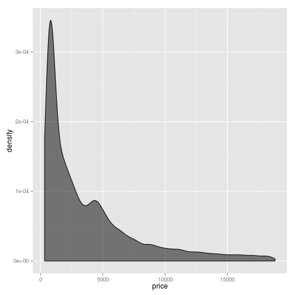

Figure 28: a basic density plot produced with ggplot2

```r
dens.ggplot <- ggplot(diamonds, aes(x = price))

g.den <- dens.ggplot +
  geom_density(fill = "black", alpha = 0.5)

print(g.den)
```

Another thing I want to highlight in the following code chunk is the way to achieve binary conditioning in `ggplot2`. This is done as follows:

```
facet_grid(g ~ f)
```

where, again, `g` and `f` are the two variables used for the conditioning.

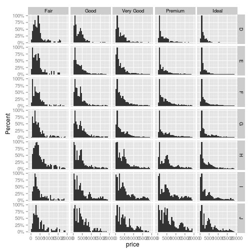

Figure 29: a ggplot2 panel histogram with y-axis labelled according to percentages

```r
g.his <- hist.ggplot +
  geom_histogram(aes(y = ..ncount..)) +
  scale_y_continuous(labels = percent_format()) +
  facet_grid(color ~ cut) +
  ylab("Percent")

print(g.his)
```

Similar to our `lattice` approach we're going to rotate the x-axis labels by 45 degrees.

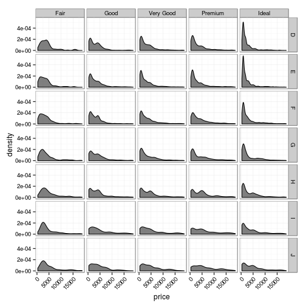

Figure 30: a ggplot2 panel density plot conditioned according to 2 variables

```r
dens.ggplot <- ggplot(diamonds, aes(x = price))

g.den <- dens.ggplot +
  geom_density(fill = "black", alpha = 0.5) +
  facet_grid(color ~ cut) +
  theme_bw() +
  theme(axis.text.x = element_text(angle = 45, hjust = 1))

print(g.den)
```

Ok, another thing we might want to show is the value of a certain estimated value (like the mean of our sample) including error bars.